# Metagenomic estimation of dietary intake from human stool - beta diversity tests for WD and MBD only

Klara Filek for Diener Lab at Med Uni Graz

2024-09-09

## Load libraries & data

Data was provided by Christian Diener (food abundance, food content and metadata) and can be found in *diets/data* of the project folder. Figures and tables are in *figures/* and *tables/* folders, respectively.

```r
library(tidyverse)
library(vegan)
library(readxl)
library(patchwork)
#library(pairwiseAdonis)

# read data and metadata
counts <- read_csv("diets/data/food_abundance.csv")
metadata <- read_xlsx("diets/data/Data merged by Daria 7-30-24.xlsx")
metadata <- rename(metadata, sample_id = Run)

# metadata with only necessary columns
meta_short <- metadata %>%
  select(sample_id, pid, diet)
```

*Optional: setting global ggplot2 theme and custom plot themes*

```r
# set global theme for ggplot
theme_set(theme_minimal())
```

## Data cleaning

Removing rows with zero counts, joining diet and sample type metadata, and pivoting wider reads and relative abundance values.

```r
# Note: RA in variable name indicates relative abundance
# join metadata and select WD and MBD diet
counts <- counts %>%
  left_join(meta_short) %>%
  filter(diet == "WD" | diet == "MBD")

# add pseudocounts
counts_pseudo <- counts %>%
  mutate(pseudoreads = reads+1) %>%
  mutate(pseudototal_reads = total_reads+1) %>%
  mutate(pseudo_RA = pseudoreads/pseudototal_reads) %>%
  mutate(logRA = log10(pseudo_RA))

# pivot to wider on raw counts (non-kraken)
# wide_counts <- counts %>%
#   select(sample_id, reads, food_id) %>%
#   pivot_wider(names_from = sample_id, values_from = reads, values_fill = 0)

# pivot to wider with relative abundances
# RA_wide_counts <- counts %>%
#   select(sample_id, relative_abundance, food_id) %>%
#   pivot_wider(names_from = sample_id, values_from = relative_abundance, values_fill = 0)
```

## Summary stats

### Number of samples per diet category

```r
# count samples per diet category
select(counts, diet, sample_id) %>%
  unique() %>%
  group_by(diet) %>%
  count()
```

```
## # A tibble: 2 × 2
## # Groups:   diet [2]
##   diet      n
##   <chr> <int>
## 1 MBD      48
## 2 WD       47
```

### Number of samples with food reads per diet category

```r
# count samples per diet category
select(counts %>% filter(reads > 0), diet, sample_id) %>%
  unique() %>%
  group_by(diet) %>%
  count()
```

```
## # A tibble: 2 × 2
## # Groups:   diet [2]
##   diet      n
##   <chr> <int>
## 1 MBD      41
## 2 WD       41
```

Six samples in WD diet, and 7 samples in MBD diet had no food reads.

### Total food counts per sample

Counts including samples with zero food counts:

```r
# summary of food counts per sample with log transformation; reads+1 and total_reads+1 because a full reads table is not available
sample_tot_counts <- counts %>%
  #drop_na(lineage) %>%
  group_by(sample_id) %>%
  summarise(sum_reads = sum(reads)) %>%
  left_join(meta_short) %>%
  left_join(unique(select(counts, sample_id, total_reads)
                   %>% group_by(sample_id))) %>%
  mutate(sumRA = sum_reads/total_reads) %>%
  mutate(pseudosum = sum_reads+1) %>%
  mutate(pseudototal = total_reads+1) %>%
  mutate(pseudoRA = pseudosum/pseudototal)
```

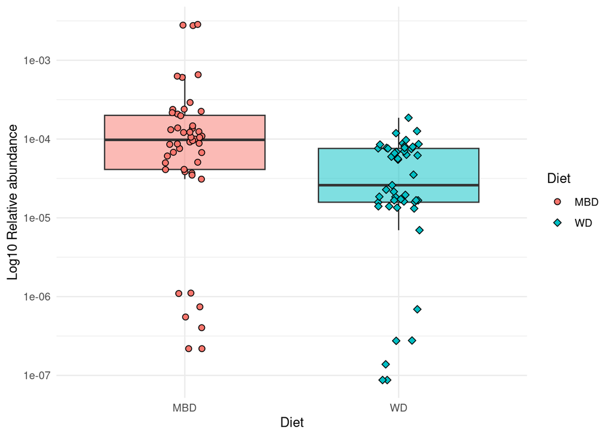

```r
# use pseudo relative abundance
boxplot_all_WD_MBD <- sample_tot_counts %>%
  ggplot() +
  geom_boxplot(aes(x = diet, y = pseudoRA, fill = diet),
               outliers = FALSE,
               show.legend = FALSE,
               #width = 0.5,
               size = 0.5,
               alpha = 0.5) +
  geom_jitter(aes(x = diet, y = pseudoRA, fill = diet, shape = diet),
              width = 0.1,
              size = 2,
              alpha = 1) +
  scale_shape_manual(values = c(21, 23)) +
  scale_y_continuous(transform = 'log10') +
  guides(fill=guide_legend(title="Diet"), shape = guide_legend(title = "Diet")) +
  labs(x = "Diet", y = "Log10 Relative abundance")

boxplot_all_WD_MBD
```

```r
ggsave("figures/boxplot_all_WD_MBD-pseudocountsRA.pdf", plot = boxplot_all_WD_MBD, width=3, height=3)
```

```r
wilcox.test(sample_tot_counts$sumRA~sample_tot_counts$diet)
```

```
##
##  Wilcoxon rank sum test with continuity correction
##
## data:  sample_tot_counts$sumRA by sample_tot_counts$diet
## W = 1662, p-value = 7.001e-05
## alternative hypothesis: true location shift is not equal to 0
```

Means per diet group

```r
# Means per diet group
mean_tot_WDMBD <- sample_tot_counts %>%
  group_by(diet) %>%
  summarize(mean_abundance = mean(sumRA), .groups = "drop")

mean_tot_WDMBD
```

```
## # A tibble: 2 × 2
##   diet  mean_abundance
##   <chr>          <dbl>
## 1 MBD        0.000297
## 2 WD         0.0000459
```

Ratio of diet group means (meanMBD/meanWD)

```r
# Calculate ratio mean(total_relative_food for MBD)/mean(total_relative_food for WD)
MBD_RA <- sample_tot_counts %>% filter(diet == "MBD")
WD_RA <- sample_tot_counts %>% filter(diet == "WD")

mean_ratio_MBD_WD <- mean(MBD_RA$sumRA)/mean(WD_RA$sumRA)
mean_ratio_MBD_WD
```

```
## [1] 6.481943
```

#### Only samples that contain food counts for visualization purposes:

```r
# summary of food counts per sample
fsample_tot_counts <- counts %>%
  drop_na(lineage) %>%
  group_by(sample_id) %>%
  summarise(sum_reads = sum(reads)) %>%
  left_join(meta_short) %>%
  left_join(unique(select(counts, sample_id, total_reads) %>% group_by(sample_id))) %>%
  mutate(sumRA = sum_reads/total_reads) #%>%
```

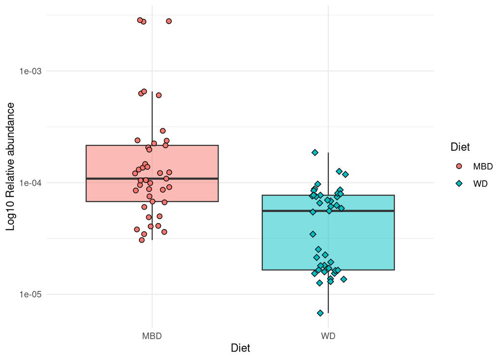

```r
  # mutate(pseudosum = sum_reads+1) %>%
  # mutate(pseudototal = total_reads+1) %>%
  # mutate(pseudoRA = pseudosum/pseudototal)

# use relative abundance, only samples containing food reads
fboxplot_all_WD_MBD <- fsample_tot_counts %>%
  ggplot() +
  geom_boxplot(aes(x = diet, y = sumRA, fill = diet),
               outliers = FALSE,
               show.legend = FALSE,
               #width = 0.5,
               size = 0.5,
               alpha = 0.5) +
  geom_jitter(aes(x = diet, y = sumRA, fill = diet, shape = diet),
              width = 0.1,
              size = 2,
              alpha = 1) +
  scale_shape_manual(values = c(21, 23)) +
  scale_y_continuous(transform = 'log10') +
  guides(fill=guide_legend(title="Diet"), shape = guide_legend(title = "Diet")) +
  labs(x = "Diet", y = "Log10 Relative abundance")

fboxplot_all_WD_MBD
```

```r
ggsave("figures/boxplot_>zero_WD_MBD-RA.pdf", plot = fboxplot_all_WD_MBD, width=3, height=3)
```

```r
wilcox.test(fsample_tot_counts$sumRA~fsample_tot_counts$diet)
```

```
##
##  Wilcoxon rank sum exact test
##
## data:  fsample_tot_counts$sumRA by fsample_tot_counts$diet
## W = 1395, p-value = 6.215e-08
## alternative hypothesis: true location shift is not equal to 0
```

Means per diet group (only samples with food reads)

```r
# Means per diet group
fmean_tot_WDMBD <- fsample_tot_counts %>%
  group_by(diet) %>%
  summarize(mean_abundance = mean(sumRA), .groups = "drop")

fmean_tot_WDMBD
```

```
## # A tibble: 2 × 2
##   diet  mean_abundance
##   <chr>          <dbl>
## 1 MBD        0.000348
## 2 WD         0.0000526
```

Ratio of diet group means (meanMBD/meanWD) (only samples with food reads)

```r
# Calculate ratio mean(total_relative_food for MBD)/mean(total_relative_food for WD)
fMBD_RA <- fsample_tot_counts %>% filter(diet == "MBD")
fWD_RA <- fsample_tot_counts %>% filter(diet == "WD")

fmean_ratio_MBD_WD <- mean(fMBD_RA$sumRA)/mean(fWD_RA$sumRA)
fmean_ratio_MBD_WD
```

```
## [1] 6.619856
```

### Barplots of relative abundances of foods detected

**Note:** colors for food items do not match across plots

Relative abundance of food reads in “WD” samples (western diet)

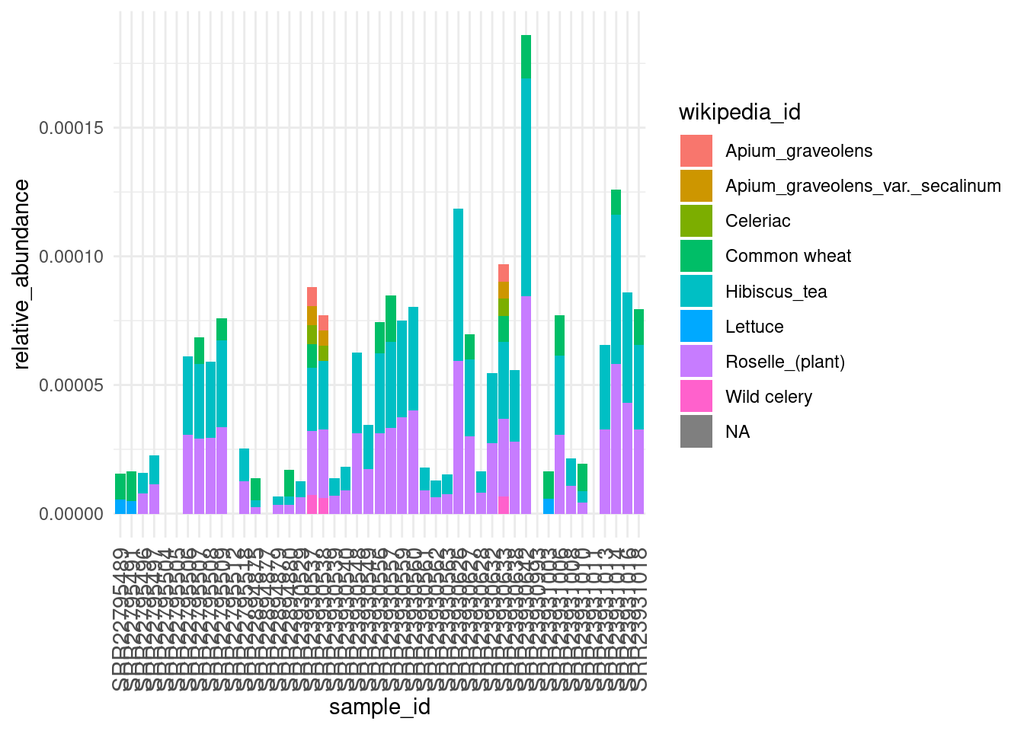

```r
counts %>%
  left_join(meta_short) %>%
  filter(diet == "WD") %>%
  ggplot(aes(x = sample_id, y = relative_abundance)) + # set "y = reads" for raw reads
  geom_bar(aes(fill = wikipedia_id), stat = "identity") +
  theme(axis.text.x = element_text(angle = 90, vjust = 0.5,
                             hjust = 0.9, size = 11,
                             color = "grey30"))
```

Relative abundance of food reads in “MBD” samples

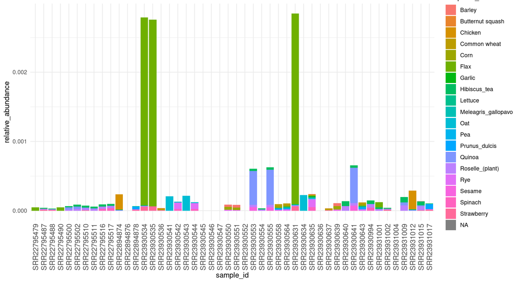

```r
counts %>%
  left_join(meta_short) %>%
  filter(diet == "MBD") %>%
  ggplot(aes(x = sample_id, y = relative_abundance)) + # set "y = reads" for raw reads
  geom_bar(aes(fill = wikipedia_id), stat = "identity") +
  theme(axis.text.x = element_text(angle = 90, vjust = 0.5,
                             hjust = 0.9, size = 11,
                             color = "grey30"))
```

### Calculate mean relative abundance of food items in diet categories

```r
# RAmeanstest <- select(counts, sample_id, food_id, relative_abundance, diet) %>%
#   pivot_wider(id_cols = food_id, )
# oops

RAmeanstest <- counts %>%
  select(sample_id, relative_abundance, food_id) %>%
  pivot_wider(names_from = sample_id, values_from = relative_abundance, values_fill = 0) %>%
  pivot_longer(cols = starts_with("SR"), names_to = "sample_id", values_to = "relative_abundance") %>%
  drop_na(food_id) %>%
  left_join(counts %>% select(sample_id, diet) %>% unique()) %>%
  left_join(counts %>% select(food_id, wikipedia_id) %>% unique() %>% drop_na(food_id))
# group by diet and food_id and then summarize
mean_abundancetestWD <- RAmeanstest %>%
  filter(diet =="WD") %>%
  group_by(food_id) %>%
  summarize(mean_abundance = mean(relative_abundance), .groups = "drop")

mean_abundancetestMBD <- RAmeanstest %>%
  filter(diet =="MBD") %>%
  group_by(food_id) %>%
  summarize(mean_abundance = mean(relative_abundance), .groups = "drop")

mean_abundancetestWD <- mean_abundancetestWD %>% rename(mean_abundance_WD = mean_abundance)
mean_abundancetestMBD <- mean_abundancetestMBD %>% rename(mean_abundance_MBD = mean_abundance)

mean_abundances <- mean_abundancetestMBD %>%
  full_join(mean_abundancetestWD) %>%
  arrange(desc(mean_abundance_MBD)) %>%
  left_join(unique(select(counts, food_id, wikipedia_id, food_group, food_subgroup)))
mean_abundances
```

```
## # A tibble: 24 × 6
##    food_id mean_abundance_MBD mean_abundance_WD wikipedia_id    food_group
##      <dbl>              <dbl>             <dbl> <chr>           <chr>
##  1     101         0.000173           0         Flax            Herbs and Spices
##  2     450         0.0000343          0         Quinoa          Herbs and Spices
##  3      22         0.0000150          0         Oat             Cereals and cer…
##  4     457         0.0000140          0.0000198 Roselle_(plant) Herbs and Spices
##  5     748         0.0000140          0.0000198 Hibiscus_tea    Teas
##  6     334         0.0000102          0         Chicken         Animal foods
##  7     169         0.00000764         0         Rye             Cereals and cer…
##  8     178         0.00000527         0         Spinach         Vegetables
##  9      83         0.00000520         0         Strawberry      Fruits
## 10     205         0.00000435         0         Corn            Cereals and cer…
## # ℹ 14 more rows
## # ℹ 1 more variable: food_subgroup <chr>
```

```r
# export table to csv file
write.table(mean_abundances, row.names = FALSE, file = "tables/mean_abudance_food_id.tsv")
```

Calculate fold change of shared food items in diet categories

```r
# fold change of mean abundances per shared food items in WD and MBD
fold_change_MBD_WD <- mean_abundances %>%
  drop_na(mean_abundance_WD, mean_abundance_MBD) %>%
  mutate(fold_changeMBDWD = mean_abundance_MBD/mean_abundance_WD)

fold_change_MBD_WD %>%
  filter(mean_abundance_MBD > 0 & mean_abundance_WD > 0)
```

```
## # A tibble: 4 × 7
##   food_id mean_abundance_MBD mean_abundance_WD wikipedia_id    food_group
##     <dbl>              <dbl>             <dbl> <chr>           <chr>
## 1     457        0.0000140         0.0000198   Roselle_(plant) Herbs and Spices
## 2     748        0.0000140         0.0000198   Hibiscus_tea    Teas
## 3     187        0.00000302        0.00000417  Common wheat    Cereals and cere…
## 4      95        0.000000594       0.000000348 Lettuce         Vegetables
## # ℹ 2 more variables: food_subgroup <chr>, fold_changeMBDWD <dbl>
```

```r
# export table to csv file
write.table(fold_change_MBD_WD, row.names = FALSE, file = "tables/fold_change_MBDtoWD.tsv")
```

### Visualize food item boxplots per food category

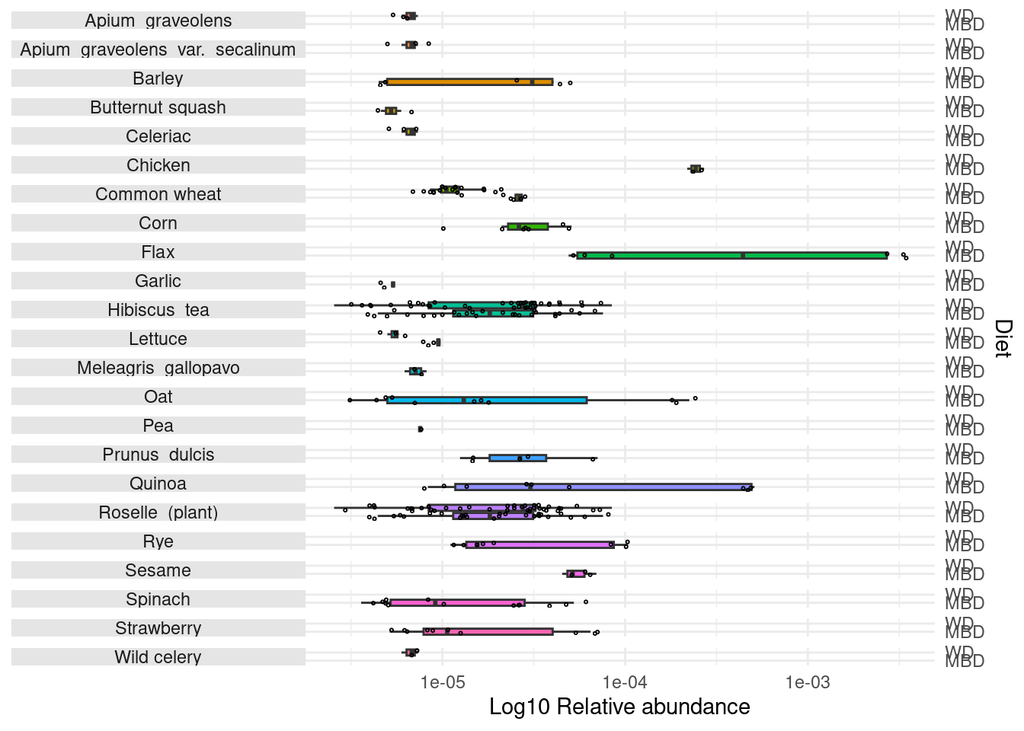

```r
food_items_RA_box <- counts %>%
  filter(reads > 0) %>%
  ggplot(aes(y = diet, x = relative_abundance, fill = wikipedia_id)) +
  geom_boxplot(size = 0.5, outliers = FALSE, show.legend = FALSE) +
  geom_jitter(show.legend = FALSE,
              shape = 1,
              width = 0.1,
              size = 0.4,
              alpha = 1) +
  facet_grid(rows = vars(wikipedia_id), switch = "y") +
  scale_x_continuous(transform = 'log10') +
  scale_y_discrete(position = "right") +
  theme(strip.text.y = element_text(angle = 0),
        strip.text.y.left = element_text(angle = 0),
        strip.background = element_rect(fill = "gray90", color = "transparent"),
        strip.placement = "outside",
        strip.switch.pad.grid = unit(5, "mm")) +
  labs(x = "Log10 Relative abundance",
       y = "Diet")

food_items_RA_box
```

```r
ggsave("figures/food_items_RA_box.pdf", plot = food_items_RA_box, width = 6, height = 8)
```

## Beta diversity

All analyses are performed on relative abundance data of WD and MBD samples.

```r
# filter to WD and MBD diet
fcounts <- counts %>%
  filter(reads > 0)

# pivot to wider with relative abundances
fRA_wide_counts <- fcounts %>%
  select(sample_id, relative_abundance, food_id) %>%
  pivot_wider(names_from = sample_id, values_from = relative_abundance, values_fill = 0)
```

Transform data and calculate Bray-Curtis distance along with PCoA and NMDS

```r
#Note: RA prefix in variable name indicates relative abundance

# transform wide tibbles in community matrix
fRA_wide_counts_df <- t(as.matrix(column_to_rownames(fRA_wide_counts, var = "food_id")))

# calculate Bray-Curtis distances
fRA_bray_dist_reads <- vegdist(fRA_wide_counts_df, method = "bray")

# PCoA
fRA_bray_dist_reads_pcoa <- cmdscale(fRA_bray_dist_reads, eig = TRUE)
fRA_bray_dist_reads_pcoa_points <-
  as_tibble(fRA_bray_dist_reads_pcoa$points, rownames = "sample_id") %>%
  rename(PC1 = V1, PC2 = V2)
# NMDS
fRA_bray_dist_reads_nmds <- metaMDS(as.matrix(fRA_bray_dist_reads),
                    k = 3,
                    maxit = 999,
                    trymax = 500,
                    wascores = TRUE)
```

```
## *** Best solution repeated 2 times
```

```r
# extract MDS1 and MDS2
fRA_bray_dist_reads_nmds_points <-
  as_tibble(fRA_bray_dist_reads_nmds$points, rownames = "sample_id") %>%
  left_join(unique(select(counts, sample_id, diet)))

# get centroids
fRA_bray_dist_reads_nmds_centr <- fRA_bray_dist_reads_nmds_points %>%
  group_by(diet) %>%
  summarize(oNMDS1 = mean(MDS1), oNMDS2 = mean(MDS2))

segs <- merge(fRA_bray_dist_reads_nmds_points, setNames(fRA_bray_dist_reads_nmds_centr, c('diet','oNMDS1','oNMDS2')),
              by = 'diet', sort = FALSE)
```

```r
# order samples to match distance matrix for adonis2
fRA_order_of_samples <- rownames(as.matrix(fRA_bray_dist_reads))
fmeta_short <- meta_short %>%
  filter(diet %in% c("WD", "MBD"))
fmeta_short_df <- fmeta_short %>% data.frame(row.names = fmeta_short$sample_id)
fmeta_short_df <- fmeta_short_df[match(fRA_order_of_samples, rownames(fmeta_short_df)), ]
print("Order of samples in metadata matches distance matrix for relative abundance:")
```

```
## [1] "Order of samples in metadata matches distance matrix for relative abundance:"
```

```r
all(rownames(fmeta_short_df) == fRA_order_of_samples)
```

```
## [1] TRUE
```

#### PERMANOVA

```r
adonis2(fRA_bray_dist_reads ~ diet, fmeta_short_df)
```

```
## Permutation test for adonis under reduced model
## Terms added sequentially (first to last)
## Permutation: free
## Number of permutations: 999
##
## adonis2(formula = fRA_bray_dist_reads ~ diet, data = fmeta_short_df)
##          Df SumOfSqs      R2      F Pr(>F)
## diet      1   2.8327 0.11055 9.9429  0.001 ***
## Residual 80  22.7915 0.88945
## Total    81  25.6241 1.00000
## ---
## Signif. codes:  0 '***' 0.001 '**' 0.01 '*' 0.05 '.' 0.1 ' ' 1
```

#### PCoA plot

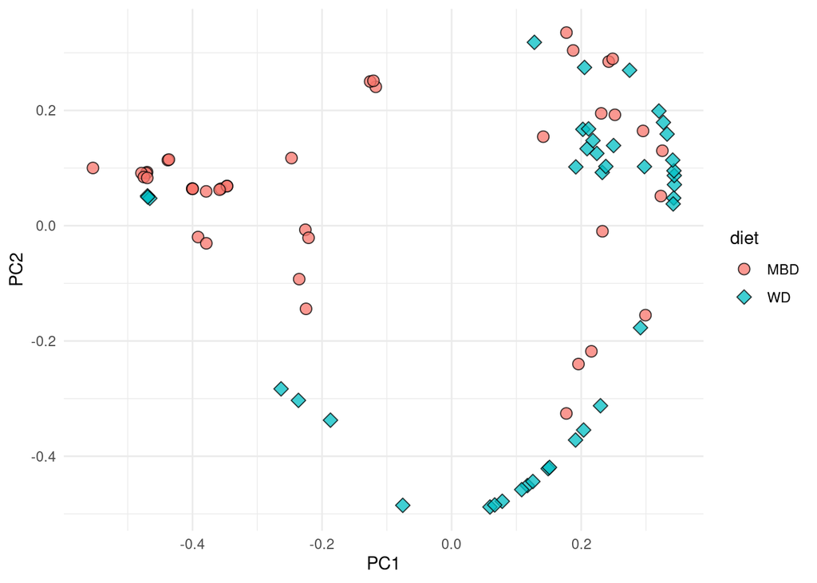

```r
# Visualize PCoA
fRA_bray_dist_reads_pcoa_points %>%
  left_join(meta_short) %>%
  ggplot() +
  geom_point(aes(x = PC1, y = PC2, fill = diet, shape = diet),
             size = 3,
             alpha = 0.75,
             color = "black") +
    scale_shape_manual(values = c(21, 23))
```

#### NMDS plots

NMDS plot with ellipses for diet types:

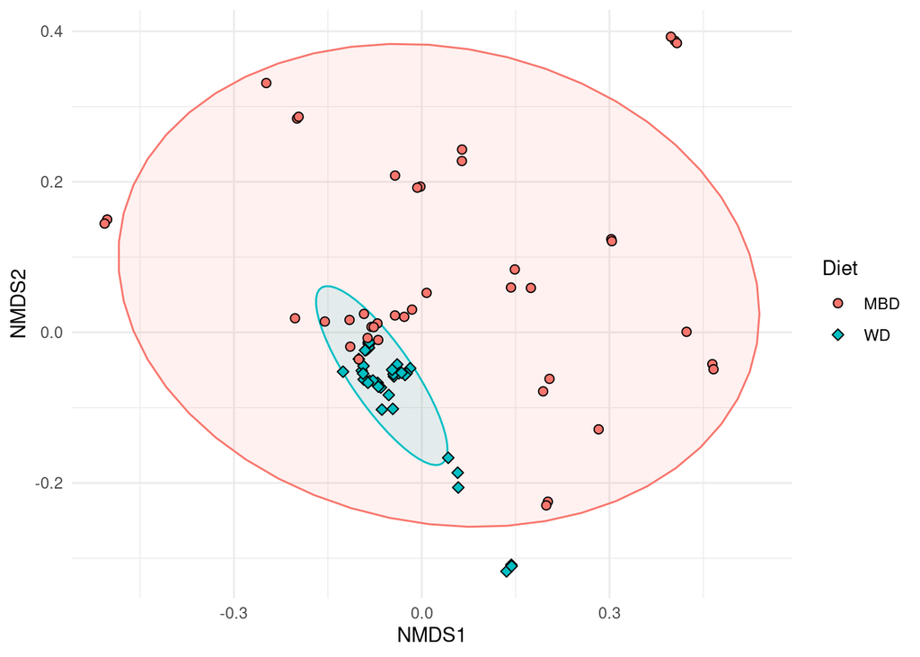

```r
# Visualize NMDS relative abundance only WD and MBD samples
library(ggforce)

NMDS_ellipses_plot <- fRA_bray_dist_reads_nmds_points %>%
  left_join(meta_short) %>%
  ggplot() +
  stat_ellipse(geom = "polygon", aes(x = MDS1, y = MDS2, color = diet, fill = diet), alpha = 0.1, show.legend = FALSE) +
  geom_point(aes(x = MDS1, y = MDS2, fill = diet, shape = diet),
             size = 2,
             alpha = 1,
             #shape = 21,
             color = "black") +
  scale_shape_manual(values = c(21, 23)) +
  guides(fill = guide_legend(title="Diet"),
         shape = guide_legend(title = "Diet")) +
  labs(x = "NMDS1", y = "NMDS2")

NMDS_ellipses_plot
```

```r
ggsave("figures/NMDS_ellipses_plot.pdf", plot = NMDS_ellipses_plot, width=4, height=3)
```

NMDS plot with centroids and samples connected to it (spider plot)

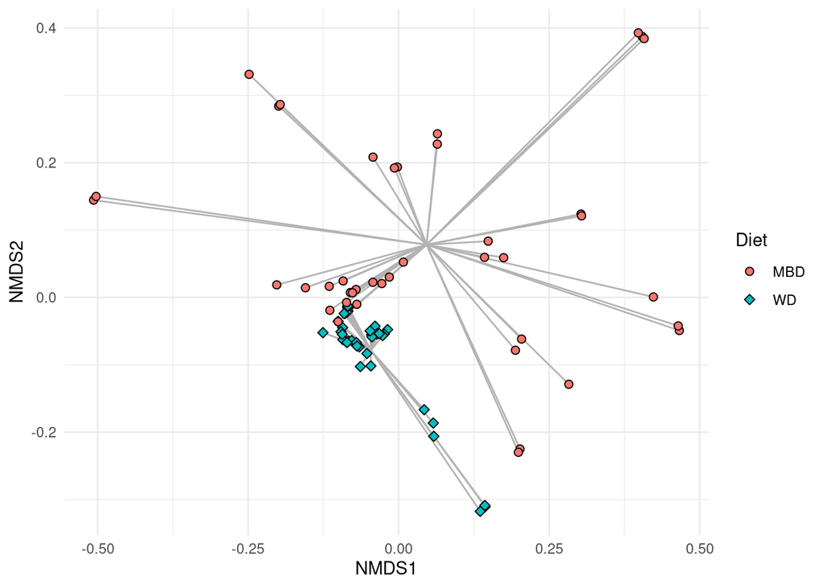

```r
# Visualize NMDS relative abundance only WD and MBD samples

NMDS_spider_plot <- segs %>%
  #left_join(meta_short) %>%
  ggplot() +
  #stat_ellipse(aes(x = MDS1, y = MDS2, color = diet)) +
  geom_segment(mapping = aes(x = MDS1, y = MDS2, xend = oNMDS1, yend = oNMDS2), color = "gray70", show.legend = FALSE) +
  #geom_point(data = fRA_bray_dist_reads_nmds_centr, aes(x = MDS1, y = MDS2, fill = diet), shape = 21, size = 5) +
  geom_point(aes(x = MDS1, y = MDS2, fill = diet, shape = diet),
             size = 2,
             alpha = 1,
             #shape = 21,
             color = "black"
             ) +
  scale_shape_manual(values = c(21, 23)) +
  guides(fill = guide_legend(title="Diet"),
         shape = guide_legend(title = "Diet")) +
  labs(x = "NMDS1", y = "NMDS2")

NMDS_spider_plot
```

```r
ggsave("figures/NMDS_spider_plot.pdf", plot = NMDS_spider_plot, width=4, height=3)
```

NMDS combined ellipses and spider plots

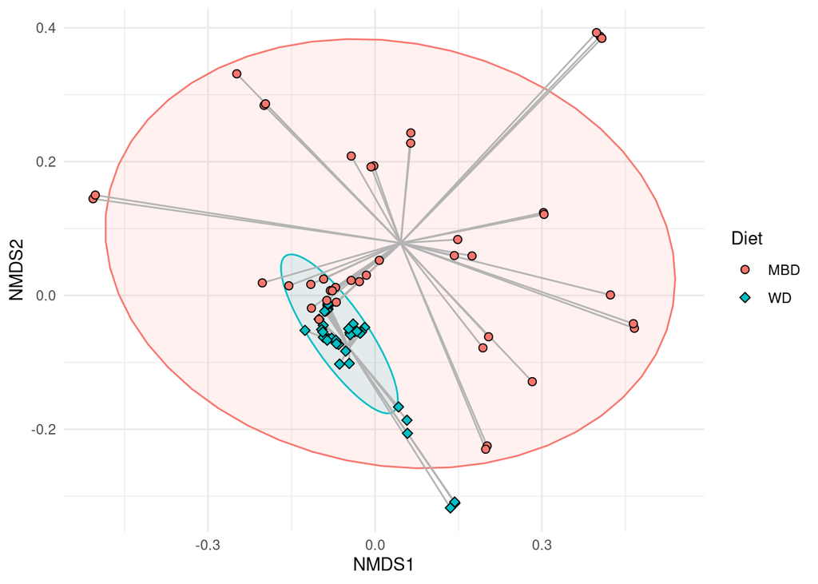

```r
# Visualize NMDS relative abundance only WD and MBD samples

NMDS_elispider_plot <- segs %>%
  #left_join(meta_short) %>%
  ggplot() +
  stat_ellipse(geom = "polygon", aes(x = MDS1, y = MDS2, color = diet, fill = diet), alpha = 0.1, show.legend = FALSE) +
  geom_segment(mapping = aes(x = MDS1, y = MDS2, xend = oNMDS1, yend = oNMDS2), color = "gray70", show.legend = FALSE) +
  #geom_point(data = fRA_bray_dist_reads_nmds_centr, aes(x = MDS1, y = MDS2, fill = diet), shape = 21, size = 5) +
  geom_point(aes(x = MDS1, y = MDS2,
                 fill = diet, shape = diet),
             size = 2,
             alpha = 1,
             #shape = 21,
             color = "black"
             ) +
  scale_shape_manual(values = c(21, 23)) +
  guides(fill = guide_legend(title="Diet"),
         shape = guide_legend(title = "Diet")) +
  labs(x = "NMDS1", y = "NMDS2")

NMDS_elispider_plot
```

```r
ggsave("figures/NMDS_elispider_plot.pdf", plot = NMDS_elispider_plot, width=4, height=3)
```

```r
print("Stress:")
```

```
## [1] "Stress:"
```

```r
fRA_bray_dist_reads_nmds$stress
```

```
## [1] 0.07252845
```

Dispersion test with PERMDISP on Bray-Curtis distances

```r
segs_dist <- segs %>%
  mutate(distance = sqrt((MDS1 - oNMDS1)^2 + (MDS2 - oNMDS2)^2))

permdisp1 <- betadisper(d = fRA_bray_dist_reads, group = fmeta_short_df$diet)

anova(permdisp1)
```

```
## Analysis of Variance Table
##
## Response: Distances
##           Df Sum Sq Mean Sq F value    Pr(>F)
## Groups     1 1.1907 1.19071  39.979 1.371e-08 ***
## Residuals 80 2.3826 0.02978
## ---
## Signif. codes:  0 '***' 0.001 '**' 0.01 '*' 0.05 '.' 0.1 ' ' 1
```

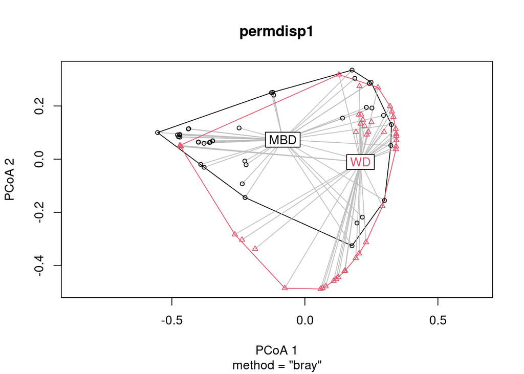

```r
plot(permdisp1)
```

# Patch the plots and save

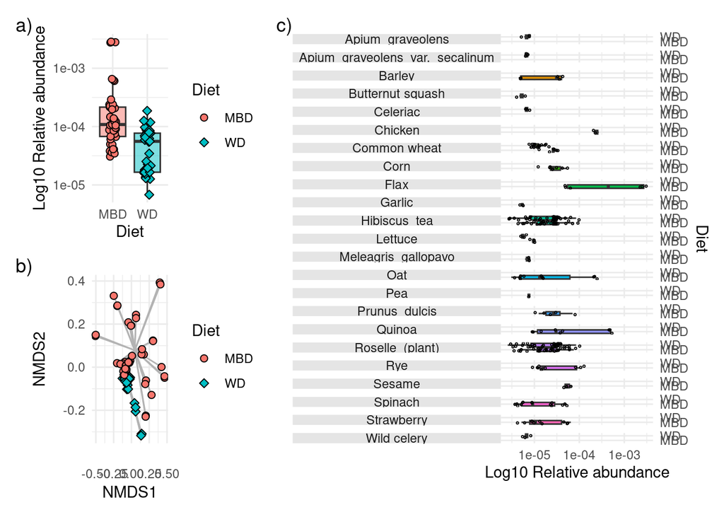

```r
p1 <- fboxplot_all_WD_MBD +
  labs(tag = "a)")

p2 <- NMDS_spider_plot +
  labs(tag = "b)")

p3 <- food_items_RA_box +
  labs(tag = "c)")

patchplot <-
(p1/p2) + p3 +
  plot_layout(design = c("ACC
                          BCC"))
patchplot
```

```r
ggsave(plot = patchplot, "figures/patchplot.pdf", width = 12, height = 9)
```